# PSYC2020L Assignment 1

[name]

2025-08-22

## Goals for Review:

- Basic R operators and data types
- Viewing data
- Basic plotting

## Setting Up

### 1) Rename this assignment as “Lab 1 Assignment [Last, First].Rmd”

### 2) Check and set your working directory

```r
getwd()
```

```
## [1] "C:/Users/jessi/OneDrive - Georgia Institute of Technology/Courses/GTA/PSYC 2020/PSYC 2020L Site/assignments"
```

We ran out of time to cover setting working directory; this is all they have to do for this question.

## R Basics

### 3) Compute:

#### a) The product of 4 * 4

```r
4 * 4
```

```
## [1] 16
```

#### b) 4 squared

```r
4 ^ 2
```

```
## [1] 16
```

```r
# or
4 ** 2
```

```
## [1] 16
```

The first one is more likely; it’s what I showed in class.

#### c) The remainder from dividing 16 by 3

```r
16 %% 3
```

```
## [1] 1
```

#### d) `FALSE` divided by `TRUE`. Why did you get this answer?

```r
FALSE / TRUE
```

```
## [1] 0
```

`FALSE` and `TRUE` are represented as 0 and 1 by R. When you divide 0 by 1, you get 0.

### 4) The output of the following two lines of code is different. Why is that?

```r
3 + 2 / 2
```

```
## [1] 4
```

```r
(3 + 2) / 2
```

```
## [1] 2.5
```

R follows standard the order of operations for math (PEMDAS). Because parentheses are evaluated first, the (3 + 2) becomes 5 in the second version, which is then divided by 2 to get 2.5. In the first version, the 2 / 2 is evaluated first, which becomes 1 and is then added to 3 to get 4.

### 4)

#### a) Create a vector of your four favorite movies

These don’t have to have output as long as the syntax is correct.

```r
my_movies <- c("Dune: Part 1", "Dune: Part 2", "Third Movie", "Fourth Movie")
```

They don’t have to assign it to a variable here; creating a vector is enough.

#### b) Create a vector of the years they came out

```r
movie_years <- c(2022, 2024, 2000, 2000)
```

They don’t have to assign it to a variable here; creating a vector is enough.

#### c) Create a vector of the ratings (number of stars out of five) that YOU think they deserve

```r
ratings <- c(5, 5, 5, 5)
```

They don’t have to assign it to a variable here; creating a vector is enough.

#### d) Put all those vectors in a dataframe with the column labels “fav_movie”, “year”, and “my_rating”

Same here, doesn’t have to have output as long as the syntax is correct.

```r
data.frame(fav_movie = my_movies,
           year = movie_years,
           my_rating = ratings)
```

```
##      fav_movie year my_rating
## 1 Dune: Part 1 2022         5
## 2 Dune: Part 2 2024         5
## 3  Third Movie 2000         5
## 4 Fourth Movie 2000         5
```

Whether they retype it by hand or use variable assignment is fine as long as the responses from a, b, and c match d. The variable names should be `fav_movie`, `year`, and `my_rating`.

### 5) Show me…

### The first three rows of the `iris` dataset

```r
head(iris, n = 3)
```

```
##   Sepal.Length Sepal.Width Petal.Length Petal.Width Species
## 1          5.1         3.5          1.4         0.2  setosa
## 2          4.9         3.0          1.4         0.2  setosa
## 3          4.7         3.2          1.3         0.2  setosa
```

### 6) Plot…

#### A scatterplot with Petal.Length on the x and Petal.Width on the y

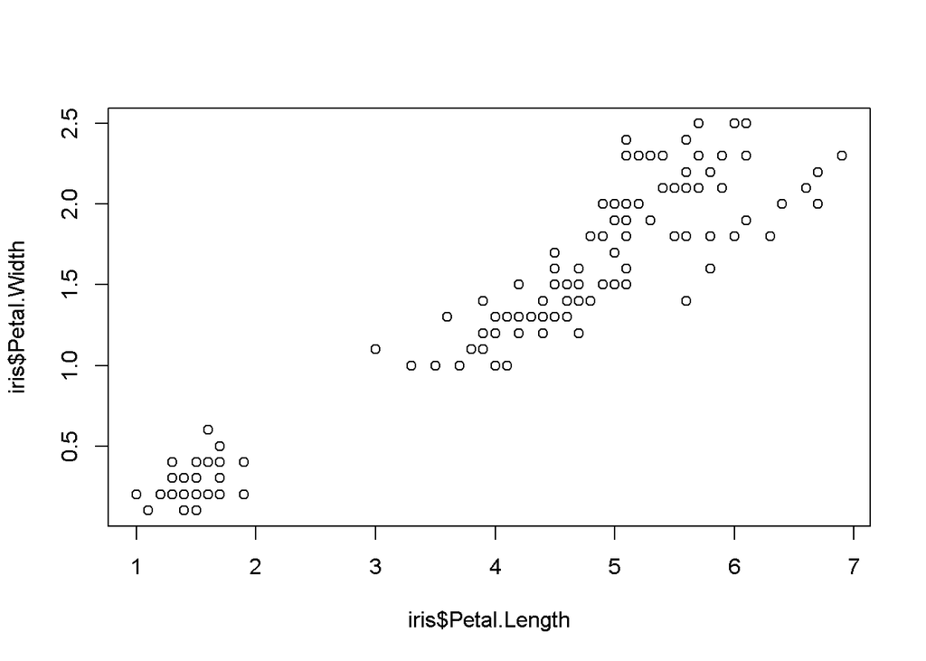

```r
plot(iris$Petal.Length, iris$Petal.Width)
```